# 8d75082e-ccca-476d-ba47-68a5a8011567

## Final project, theme "Industry".

### Problem condition

In order to optimize production costs, the metallurgical plant "Temper steel" decided to reduce electricity consumption at the stage of steel processing. You have to build a model that predicts the temperature of the steel.

### Description of the processing step

Steel is processed in a metal ladle with a capacity of about 100 tons. To withstand high temperatures, the ladle is lined with refractory bricks from the inside. Molten steel is poured into a ladle and heated to the desired temperature with graphite electrodes. They are installed in the lid of the bucket.

Sulfur is removed from the alloy (desulfurization), the chemical composition is corrected by adding impurities, and samples are taken. Steel is alloyed - its composition is changed - by feeding pieces of alloy from a bunker for bulk materials or wire through a special tribe apparatus.

Before introducing alloying additives for the first time, the temperature of the steel is measured and its chemical analysis is carried out. Then the temperature is raised for several minutes, alloying materials are added and the alloy is purged with an inert gas. Then it is stirred and measured again. This cycle is repeated until the target chemical composition and optimum melting temperature are reached.

Then the molten steel is sent to finish the metal or enters the continuous casting machine. From there, the finished product comes out in the form of slabs.

### Data Description

The data consists of files obtained from various sources:

- `data_arc.csv` — data on electrodes;
- `data_bulk.csv` — data on the supply of bulk materials (volume);
- `data_bulk_time.csv` — data on the supply of bulk materials (time);
- `data_gas.csv` — data on alloy gas purge;
- `data_temp.csv` — temperature measurement results;
- `data_wire.csv` — data on wire materials (volume);
- `data_wire_time.csv` — wire material data (time).

In all files, the key column contains the batch number. Files can have multiple lines with the same key value: they correspond to different processing iterations.

First, load the necessary libraries in a separate cell before starting work:

```python
import pandas as pd
import numpy as np
import matplotlib.pyplot as plt
import seaborn as sns
import warnings
warnings.filterwarnings('ignore')

from scipy import stats as st
from sklearn.model_selection import train_test_split
from sklearn.metrics import mean_absolute_error
from sklearn.model_selection import cross_val_score
from sklearn.model_selection import GridSearchCV
from pyod.models.knn import KNN
from sklearn.linear_model import LinearRegression
from sklearn.ensemble import RandomForestRegressor
from catboost import CatBoostRegressor
from lightgbm import LGBMRegressor
```

```python
#pip install pyod
```

Let's look at each table in detail and build graphs to see the distribution of data.

##### Electrode data.

```python
data_arc = pd.read_csv(r'C:\Users\MaYu7006\Documents\info_math\yandex ds\final\data_arc.csv')
data_arc.head(20)
```

|  | key | Начало нагрева дугой | Конец нагрева дугой | Активная мощность | Реактивная мощность |
| --- | --- | --- | --- | --- | --- |
| 0 | 1 | 2019-05-03 11:02:14 | 2019-05-03 11:06:02 | 0.976059 | 0.687084 |
| 1 | 1 | 2019-05-03 11:07:28 | 2019-05-03 11:10:33 | 0.805607 | 0.520285 |
| 2 | 1 | 2019-05-03 11:11:44 | 2019-05-03 11:14:36 | 0.744363 | 0.498805 |
| 3 | 1 | 2019-05-03 11:18:14 | 2019-05-03 11:24:19 | 1.659363 | 1.062669 |
| 4 | 1 | 2019-05-03 11:26:09 | 2019-05-03 11:28:37 | 0.692755 | 0.414397 |
| 5 | 2 | 2019-05-03 11:34:14 | 2019-05-03 11:36:31 | 0.438063 | 0.283043 |
| 6 | 2 | 2019-05-03 11:38:50 | 2019-05-03 11:44:28 | 1.296415 | 0.892914 |
| 7 | 2 | 2019-05-03 11:46:19 | 2019-05-03 11:48:25 | 0.490377 | 0.305281 |
| 8 | 2 | 2019-05-03 11:49:48 | 2019-05-03 11:53:18 | 0.827743 | 0.516874 |
| 9 | 3 | 2019-05-03 12:06:54 | 2019-05-03 12:11:34 | 1.062053 | 0.671494 |
| 10 | 3 | 2019-05-03 12:13:52 | 2019-05-03 12:15:56 | 0.484206 | 0.312100 |
| 11 | 3 | 2019-05-03 12:18:56 | 2019-05-03 12:20:45 | 0.429355 | 0.271774 |
| 12 | 3 | 2019-05-03 12:25:43 | 2019-05-03 12:27:00 | 0.299989 | 0.187806 |
| 13 | 3 | 2019-05-03 12:31:14 | 2019-05-03 12:32:19 | 0.250280 | 0.155901 |
| 14 | 4 | 2019-05-03 12:39:37 | 2019-05-03 12:43:04 | 0.875313 | 0.614404 |
| 15 | 4 | 2019-05-03 12:44:47 | 2019-05-03 12:46:26 | 0.425692 | 0.268482 |
| 16 | 4 | 2019-05-03 12:48:14 | 2019-05-03 12:50:51 | 0.687289 | 0.422692 |
| 17 | 4 | 2019-05-03 12:53:12 | 2019-05-03 12:57:50 | 1.220955 | 0.754719 |
| 18 | 5 | 2019-05-03 13:11:13 | 2019-05-03 13:15:24 | 0.950026 | 0.690523 |
| 19 | 5 | 2019-05-03 13:18:21 | 2019-05-03 13:20:33 | 0.508026 | 0.332352 |

```python
data_arc.info()
```

```
<class 'pandas.core.frame.DataFrame'>
RangeIndex: 14876 entries, 0 to 14875
Data columns (total 5 columns):
 #   Column                Non-Null Count  Dtype
---  ------                --------------  -----
 0   key                   14876 non-null  int64
 1   Начало нагрева дугой  14876 non-null  object
 2   Конец нагрева дугой   14876 non-null  object
 3   Активная мощность     14876 non-null  float64
 4   Реактивная мощность   14876 non-null  float64
dtypes: float64(2), int64(1), object(2)
memory usage: 581.2+ KB
```

```python
data_arc['key'].unique()
```

```
array([   1,    2,    3, ..., 3239, 3240, 3241], dtype=int64)
```

```python
data_arc.isnull().sum()
```

```
key                     0
Начало нагрева дугой    0
Конец нагрева дугой     0
Активная мощность       0
Реактивная мощность     0
dtype: int64
```

Let's build graphs and information for the columns 'Активная мощность' ('Active power') and 'Реактивная мощность' ('Reactive power').

```python
data_arc['Активная мощность'].describe()
```

```
count    14876.000000
mean         0.670441
std          0.408159
min          0.030002
25%          0.395297
50%          0.555517
75%          0.857034
max          3.731596
Name: Активная мощность, dtype: float64
```

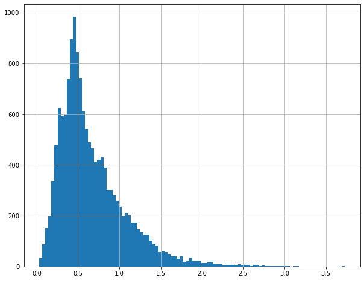

```python
data_arc['Активная мощность'].hist(bins=100, figsize=(10, 8))
```

```python
data_arc['Реактивная мощность'].describe()
```

```
count    14876.000000
mean         0.452592
std          5.878702
min       -715.504924
25%          0.290991
50%          0.415962
75%          0.637371
max          2.676388
Name: Реактивная мощность, dtype: float64
```

It is unlikely that 'Реактивная мощность' ('Reactive power') can be negative, so let's see how many such values there are in total.

```python
data_arc[data_arc['Реактивная мощность'] < 0].count()
```

```
key                     1
Начало нагрева дугой    1
Конец нагрева дугой     1
Активная мощность       1
Реактивная мощность     1
dtype: int64
```

We see that only one value in the table is less than 0 and is very different from the others. Most likely this is a mistake, so it is better to delete this line so as not to spoil the data.

```python
data_arc = data_arc[data_arc["Реактивная мощность"] > 0]
```

```python
data_arc['Реактивная мощность'].describe()
```

```
count    14875.000000
mean         0.500723
std          0.310880
min          0.020806
25%          0.291003
50%          0.415984
75%          0.637403
max          2.676388
Name: Реактивная мощность, dtype: float64
```

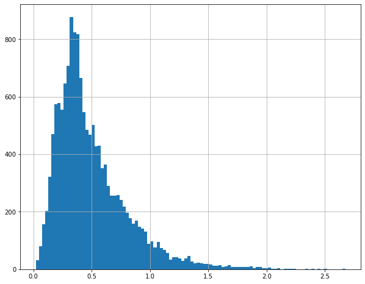

```python
data_arc['Реактивная мощность'].hist(bins=100, figsize=(10, 8))
```

#### Bulk material feed data (volume)¶

```python
data_bulk = pd.read_csv(r'C:\Users\MaYu7006\Documents\info_math\yandex ds\final\data_bulk.csv')
data_bulk.head(10)
```

|  | key | Bulk 1 | Bulk 2 | Bulk 3 | Bulk 4 | Bulk 5 | Bulk 6 | Bulk 7 | Bulk 8 | Bulk 9 | Bulk 10 | Bulk 11 | Bulk 12 | Bulk 13 | Bulk 14 | Bulk 15 |
| --- | --- | --- | --- | --- | --- | --- | --- | --- | --- | --- | --- | --- | --- | --- | --- | --- |
| 0 | 1 | NaN | NaN | NaN | 43.0 | NaN | NaN | NaN | NaN | NaN | NaN | NaN | 206.0 | NaN | 150.0 | 154.0 |
| 1 | 2 | NaN | NaN | NaN | 73.0 | NaN | NaN | NaN | NaN | NaN | NaN | NaN | 206.0 | NaN | 149.0 | 154.0 |
| 2 | 3 | NaN | NaN | NaN | 34.0 | NaN | NaN | NaN | NaN | NaN | NaN | NaN | 205.0 | NaN | 152.0 | 153.0 |
| 3 | 4 | NaN | NaN | NaN | 81.0 | NaN | NaN | NaN | NaN | NaN | NaN | NaN | 207.0 | NaN | 153.0 | 154.0 |
| 4 | 5 | NaN | NaN | NaN | 78.0 | NaN | NaN | NaN | NaN | NaN | NaN | NaN | 203.0 | NaN | 151.0 | 152.0 |
| 5 | 6 | NaN | NaN | NaN | 117.0 | NaN | NaN | NaN | NaN | NaN | NaN | NaN | 204.0 | NaN | 201.0 | 154.0 |
| 6 | 7 | NaN | NaN | NaN | 117.0 | NaN | NaN | NaN | NaN | NaN | NaN | NaN | 204.0 | NaN | 152.0 | 154.0 |
| 7 | 8 | NaN | NaN | NaN | 99.0 | NaN | NaN | NaN | NaN | NaN | NaN | NaN | 410.0 | NaN | 252.0 | 153.0 |
| 8 | 9 | NaN | NaN | NaN | 117.0 | NaN | NaN | NaN | NaN | NaN | NaN | NaN | 107.0 | NaN | 99.0 | 203.0 |
| 9 | 10 | NaN | NaN | NaN | NaN | NaN | NaN | NaN | NaN | NaN | NaN | NaN | 203.0 | NaN | 102.0 | 204.0 |

```python
data_bulk.info()
```

```
<class 'pandas.core.frame.DataFrame'>
RangeIndex: 3129 entries, 0 to 3128
Data columns (total 16 columns):
 #   Column   Non-Null Count  Dtype
---  ------   --------------  -----
 0   key      3129 non-null   int64
 1   Bulk 1   252 non-null    float64
 2   Bulk 2   22 non-null     float64
 3   Bulk 3   1298 non-null   float64
 4   Bulk 4   1014 non-null   float64
 5   Bulk 5   77 non-null     float64
 6   Bulk 6   576 non-null    float64
 7   Bulk 7   25 non-null     float64
 8   Bulk 8   1 non-null      float64
 9   Bulk 9   19 non-null     float64
 10  Bulk 10  176 non-null    float64
 11  Bulk 11  177 non-null    float64
 12  Bulk 12  2450 non-null   float64
 13  Bulk 13  18 non-null     float64
 14  Bulk 14  2806 non-null   float64
 15  Bulk 15  2248 non-null   float64
dtypes: float64(15), int64(1)
memory usage: 391.2 KB
```

Let's see the information about each column:

```python
for column in data_bulk.columns:
    print(column)
    display(data_bulk[column].describe())
```

```
key
```

```
count    3129.000000
mean     1624.383509
std       933.337642
min         1.000000
25%       816.000000
50%      1622.000000
75%      2431.000000
max      3241.000000
Name: key, dtype: float64
```

```
Bulk 1
```

```
count    252.000000
mean      39.242063
std       18.277654
min       10.000000
25%       27.000000
50%       31.000000
75%       46.000000
max      185.000000
Name: Bulk 1, dtype: float64
```

```
Bulk 2
```

```
count     22.000000
mean     253.045455
std       21.180578
min      228.000000
25%      242.000000
50%      251.500000
75%      257.750000
max      325.000000
Name: Bulk 2, dtype: float64
```

```
Bulk 3
```

```
count    1298.000000
mean      113.879045
std        75.483494
min         6.000000
25%        58.000000
50%        97.500000
75%       152.000000
max       454.000000
Name: Bulk 3, dtype: float64
```

```
Bulk 4
```

```
count    1014.000000
mean      104.394477
std        48.184126
min        12.000000
25%        72.000000
50%       102.000000
75%       133.000000
max       281.000000
Name: Bulk 4, dtype: float64
```

```
Bulk 5
```

```
count     77.000000
mean     107.025974
std       81.790646
min       11.000000
25%       70.000000
50%       86.000000
75%      132.000000
max      603.000000
Name: Bulk 5, dtype: float64
```

```
Bulk 6
```

```
count    576.000000
mean     118.925347
std       72.057776
min       17.000000
25%       69.750000
50%      100.000000
75%      157.000000
max      503.000000
Name: Bulk 6, dtype: float64
```

```
Bulk 7
```

```
count     25.000000
mean     305.600000
std      191.022904
min       47.000000
25%      155.000000
50%      298.000000
75%      406.000000
max      772.000000
Name: Bulk 7, dtype: float64
```

```
Bulk 8
```

```
count     1.0
mean     49.0
std       NaN
min      49.0
25%      49.0
50%      49.0
75%      49.0
max      49.0
Name: Bulk 8, dtype: float64
```

```
Bulk 9
```

```
count     19.000000
mean      76.315789
std       21.720581
min       63.000000
25%       66.000000
50%       68.000000
75%       70.500000
max      147.000000
Name: Bulk 9, dtype: float64
```

```
Bulk 10
```

```
count    176.000000
mean      83.284091
std       26.060347
min       24.000000
25%       64.000000
50%       86.500000
75%      102.000000
max      159.000000
Name: Bulk 10, dtype: float64
```

```
Bulk 11
```

```
count    177.000000
mean      76.819209
std       59.655365
min        8.000000
25%       25.000000
50%       64.000000
75%      106.000000
max      313.000000
Name: Bulk 11, dtype: float64
```

```
Bulk 12
```

```
count    2450.000000
mean      260.471020
std       120.649269
min        53.000000
25%       204.000000
50%       208.000000
75%       316.000000
max      1849.000000
Name: Bulk 12, dtype: float64
```

```
Bulk 13
```

```
count     18.000000
mean     181.111111
std       46.088009
min      151.000000
25%      153.250000
50%      155.500000
75%      203.500000
max      305.000000
Name: Bulk 13, dtype: float64
```

```
Bulk 14
```

```
count    2806.000000
mean      170.284747
std        65.868652
min        16.000000
25%       119.000000
50%       151.000000
75%       205.750000
max       636.000000
Name: Bulk 14, dtype: float64
```

```
Bulk 15
```

```
count    2248.000000
mean      160.513345
std        51.765319
min         1.000000
25%       105.000000
50%       160.000000
75%       205.000000
max       405.000000
Name: Bulk 15, dtype: float64
```

Now let's build a graph for each column:

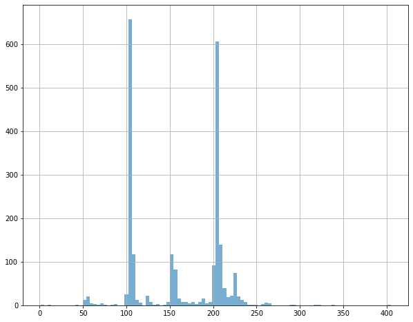

```python
data_bulk[column].hist(bins=100, figsize=(10, 8), alpha=0.6)
```

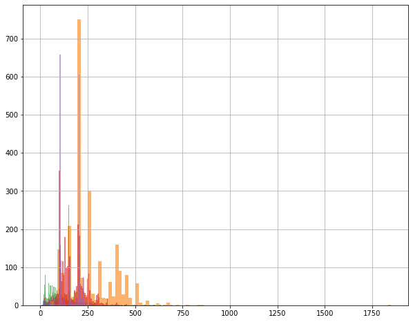

```python
for column in data_bulk.columns:
    if column[0] == 'B':
        data_bulk[column].hist(bins=100, figsize=(10, 8), alpha=0.6)
```

#### Bulk materials feeding data (time)

```python
data_bulk_time = pd.read_csv(r'C:\Users\MaYu7006\Documents\info_math\yandex ds\final\data_bulk_time.csv')
data_bulk_time.head(10)
```

|  | key | Bulk 1 | Bulk 2 | Bulk 3 | Bulk 4 | Bulk 5 | Bulk 6 | Bulk 7 | Bulk 8 | Bulk 9 | Bulk 10 | Bulk 11 | Bulk 12 | Bulk 13 | Bulk 14 | Bulk 15 |
| --- | --- | --- | --- | --- | --- | --- | --- | --- | --- | --- | --- | --- | --- | --- | --- | --- |
| 0 | 1 | NaN | NaN | NaN | 2019-05-03 11:21:30 | NaN | NaN | NaN | NaN | NaN | NaN | NaN | 2019-05-03 11:03:52 | NaN | 2019-05-03 11:03:52 | 2019-05-03 11:03:52 |
| 1 | 2 | NaN | NaN | NaN | 2019-05-03 11:46:38 | NaN | NaN | NaN | NaN | NaN | NaN | NaN | 2019-05-03 11:40:20 | NaN | 2019-05-03 11:40:20 | 2019-05-03 11:40:20 |
| 2 | 3 | NaN | NaN | NaN | 2019-05-03 12:31:06 | NaN | NaN | NaN | NaN | NaN | NaN | NaN | 2019-05-03 12:09:40 | NaN | 2019-05-03 12:09:40 | 2019-05-03 12:09:40 |
| 3 | 4 | NaN | NaN | NaN | 2019-05-03 12:48:43 | NaN | NaN | NaN | NaN | NaN | NaN | NaN | 2019-05-03 12:41:24 | NaN | 2019-05-03 12:41:24 | 2019-05-03 12:41:24 |
| 4 | 5 | NaN | NaN | NaN | 2019-05-03 13:18:50 | NaN | NaN | NaN | NaN | NaN | NaN | NaN | 2019-05-03 13:12:56 | NaN | 2019-05-03 13:12:56 | 2019-05-03 13:12:56 |
| 5 | 6 | NaN | NaN | NaN | 2019-05-03 13:59:24 | NaN | NaN | NaN | NaN | NaN | NaN | NaN | 2019-05-03 13:53:27 | NaN | 2019-05-03 13:53:27 | 2019-05-03 13:53:27 |
| 6 | 7 | NaN | NaN | NaN | 2019-05-03 14:29:14 | NaN | NaN | NaN | NaN | NaN | NaN | NaN | 2019-05-03 14:22:19 | NaN | 2019-05-03 14:22:19 | 2019-05-03 14:22:19 |
| 7 | 8 | NaN | NaN | NaN | 2019-05-03 15:04:05 | NaN | NaN | NaN | NaN | NaN | NaN | NaN | 2019-05-03 14:55:46 | NaN | 2019-05-03 14:55:46 | 2019-05-03 14:55:46 |
| 8 | 9 | NaN | NaN | NaN | 2019-05-03 15:47:34 | NaN | NaN | NaN | NaN | NaN | NaN | NaN | 2019-05-03 15:41:00 | NaN | 2019-05-03 15:41:00 | 2019-05-03 15:41:00 |
| 9 | 10 | NaN | NaN | NaN | NaN | NaN | NaN | NaN | NaN | NaN | NaN | NaN | 2019-05-03 16:18:52 | NaN | 2019-05-03 16:18:52 | 2019-05-03 16:18:52 |

```python
data_bulk_time.info()
```

```
<class 'pandas.core.frame.DataFrame'>
RangeIndex: 3129 entries, 0 to 3128
Data columns (total 16 columns):
 #   Column   Non-Null Count  Dtype
---  ------   --------------  -----
 0   key      3129 non-null   int64
 1   Bulk 1   252 non-null    object
 2   Bulk 2   22 non-null     object
 3   Bulk 3   1298 non-null   object
 4   Bulk 4   1014 non-null   object
 5   Bulk 5   77 non-null     object
 6   Bulk 6   576 non-null    object
 7   Bulk 7   25 non-null     object
 8   Bulk 8   1 non-null      object
 9   Bulk 9   19 non-null     object
 10  Bulk 10  176 non-null    object
 11  Bulk 11  177 non-null    object
 12  Bulk 12  2450 non-null   object
 13  Bulk 13  18 non-null     object
 14  Bulk 14  2806 non-null   object
 15  Bulk 15  2248 non-null   object
dtypes: int64(1), object(15)
memory usage: 391.2+ KB
```

```python
for column in data_bulk_time.columns:
    print(column)
    display(data_bulk_time[column].describe())
```

```
key
```

```
count    3129.000000
mean     1624.383509
std       933.337642
min         1.000000
25%       816.000000
50%      1622.000000
75%      2431.000000
max      3241.000000
Name: key, dtype: float64
```

```
Bulk 1
```

```
count                     252
unique                    252
top       2019-07-26 14:25:20
freq                        1
Name: Bulk 1, dtype: object
```

```
Bulk 2
```

```
count                      22
unique                     22
top       2019-07-23 08:42:23
freq                        1
Name: Bulk 2, dtype: object
```

```
Bulk 3
```

```
count                    1298
unique                   1298
top       2019-08-15 12:37:33
freq                        1
Name: Bulk 3, dtype: object
```

```
Bulk 4
```

```
count                    1014
unique                   1014
top       2019-06-07 03:24:57
freq                        1
Name: Bulk 4, dtype: object
```

```
Bulk 5
```

```
count                      77
unique                     77
top       2019-07-21 23:25:54
freq                        1
Name: Bulk 5, dtype: object
```

```
Bulk 6
```

```
count                     576
unique                    576
top       2019-08-01 20:02:49
freq                        1
Name: Bulk 6, dtype: object
```

```
Bulk 7
```

```
count                      25
unique                     25
top       2019-08-08 11:21:17
freq                        1
Name: Bulk 7, dtype: object
```

```
Bulk 8
```

```
count                       1
unique                      1
top       2019-07-05 17:46:11
freq                        1
Name: Bulk 8, dtype: object
```

```
Bulk 9
```

```
count                      19
unique                     19
top       2019-05-14 00:04:56
freq                        1
Name: Bulk 9, dtype: object
```

```
Bulk 10
```

```
count                     176
unique                    176
top       2019-05-31 21:44:40
freq                        1
Name: Bulk 10, dtype: object
```

```
Bulk 11
```

```
count                     177
unique                    177
top       2019-08-17 04:44:35
freq                        1
Name: Bulk 11, dtype: object
```

```
Bulk 12
```

```
count                    2450
unique                   2450
top       2019-06-21 06:41:17
freq                        1
Name: Bulk 12, dtype: object
```

```
Bulk 13
```

```
count                      18
unique                     18
top       2019-05-31 04:40:34
freq                        1
Name: Bulk 13, dtype: object
```

```
Bulk 14
```

```
count                    2806
unique                   2806
top       2019-06-21 06:41:17
freq                        1
Name: Bulk 14, dtype: object
```

```
Bulk 15
```

```
count                    2248
unique                   2248
top       2019-06-21 06:41:17
freq                        1
Name: Bulk 15, dtype: object
```

```python
data_bulk_time['key'].unique()
```

```
array([   1,    2,    3, ..., 3239, 3240, 3241], dtype=int64)
```

#### Data on the purge of the alloy with gas.

```python
data_gas = pd.read_csv(r'C:\Users\MaYu7006\Documents\info_math\yandex ds\final\data_gas.csv')
data_gas.head(10)
```

|  | key | Газ 1 |
| --- | --- | --- |
| 0 | 1 | 29.749986 |
| 1 | 2 | 12.555561 |
| 2 | 3 | 28.554793 |
| 3 | 4 | 18.841219 |
| 4 | 5 | 5.413692 |
| 5 | 6 | 11.273392 |
| 6 | 7 | 9.836267 |
| 7 | 8 | 15.171553 |
| 8 | 9 | 8.216623 |
| 9 | 10 | 6.529891 |

```python
data_gas.describe()
```

|  | key | Газ 1 |
| --- | --- | --- |
| count | 3239.000000 | 3239.000000 |
| mean | 1621.861377 | 11.002062 |
| std | 935.386334 | 6.220327 |
| min | 1.000000 | 0.008399 |
| 25% | 812.500000 | 7.043089 |
| 50% | 1622.000000 | 9.836267 |
| 75% | 2431.500000 | 13.769915 |
| max | 3241.000000 | 77.995040 |

```python
data_gas['key'].unique()
```

```
array([   1,    2,    3, ..., 3239, 3240, 3241], dtype=int64)
```

```python
data_gas.isnull().sum()
```

```
key      0
Газ 1    0
dtype: int64
```

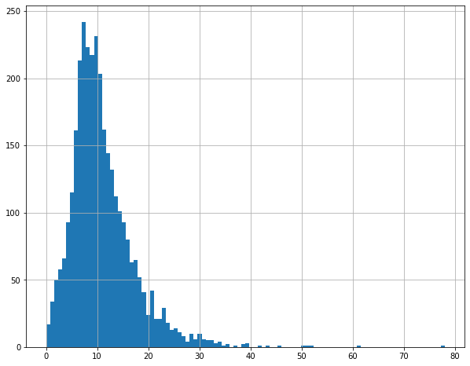

```python
data_gas['Газ 1'].hist(bins=100, figsize=(10, 8))
```

#### Temperature measurement results:

```python
data_temp = pd.read_csv(r'C:\Users\MaYu7006\Documents\info_math\yandex ds\final\data_temp.csv')
data_temp.head(10)
```

|  | key | Время замера | Температура |
| --- | --- | --- | --- |
| 0 | 1 | 2019-05-03 11:16:18 | 1571.0 |
| 1 | 1 | 2019-05-03 11:25:53 | 1604.0 |
| 2 | 1 | 2019-05-03 11:29:11 | 1618.0 |
| 3 | 1 | 2019-05-03 11:30:01 | 1601.0 |
| 4 | 1 | 2019-05-03 11:30:39 | 1613.0 |
| 5 | 2 | 2019-05-03 11:37:27 | 1581.0 |
| 6 | 2 | 2019-05-03 11:38:00 | 1577.0 |
| 7 | 2 | 2019-05-03 11:49:38 | 1589.0 |
| 8 | 2 | 2019-05-03 11:55:50 | 1604.0 |
| 9 | 2 | 2019-05-03 11:58:24 | 1608.0 |

```python
data_temp.info()
```

```
<class 'pandas.core.frame.DataFrame'>
RangeIndex: 15907 entries, 0 to 15906
Data columns (total 3 columns):
 #   Column        Non-Null Count  Dtype
---  ------        --------------  -----
 0   key           15907 non-null  int64
 1   Время замера  15907 non-null  object
 2   Температура   13006 non-null  float64
dtypes: float64(1), int64(1), object(1)
memory usage: 372.9+ KB
```

```python
data_temp['key'].unique()
```

```
array([   1,    2,    3, ..., 3239, 3240, 3241], dtype=int64)
```

```python
data_temp['Температура'].describe()
```

```
count    13006.000000
mean      1591.840920
std         21.375851
min       1191.000000
25%       1581.000000
50%       1591.000000
75%       1601.000000
max       1705.000000
Name: Температура, dtype: float64
```

```python
data_temp.isnull().sum()
```

```
key                0
Время замера       0
Температура     2901
dtype: int64
```

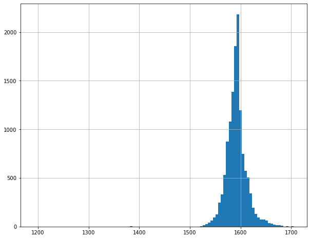

```python
data_temp['Температура'].hist(bins=100, figsize=(10,8))
```

#### Wire materials data (volume):

```python
data_wire = pd.read_csv(r'C:\Users\MaYu7006\Documents\info_math\yandex ds\final\data_wire.csv')
data_wire.head(10)
```

|  | key | Wire 1 | Wire 2 | Wire 3 | Wire 4 | Wire 5 | Wire 6 | Wire 7 | Wire 8 | Wire 9 |
| --- | --- | --- | --- | --- | --- | --- | --- | --- | --- | --- |
| 0 | 1 | 60.059998 | NaN | NaN | NaN | NaN | NaN | NaN | NaN | NaN |
| 1 | 2 | 96.052315 | NaN | NaN | NaN | NaN | NaN | NaN | NaN | NaN |
| 2 | 3 | 91.160157 | NaN | NaN | NaN | NaN | NaN | NaN | NaN | NaN |
| 3 | 4 | 89.063515 | NaN | NaN | NaN | NaN | NaN | NaN | NaN | NaN |
| 4 | 5 | 89.238236 | 9.114560 | NaN | NaN | NaN | NaN | NaN | NaN | NaN |
| 5 | 6 | 99.109917 | 9.114560 | NaN | NaN | NaN | NaN | NaN | NaN | NaN |
| 6 | 7 | 98.061600 | NaN | NaN | NaN | NaN | NaN | NaN | NaN | NaN |
| 7 | 8 | 155.282394 | NaN | NaN | NaN | NaN | NaN | NaN | NaN | NaN |
| 8 | 9 | 113.393279 | 9.143681 | NaN | NaN | NaN | NaN | NaN | NaN | NaN |
| 9 | 10 | 81.244796 | 12.376000 | NaN | NaN | NaN | NaN | NaN | NaN | NaN |

```python
data_wire.info()
```

```
<class 'pandas.core.frame.DataFrame'>
RangeIndex: 3081 entries, 0 to 3080
Data columns (total 10 columns):
 #   Column  Non-Null Count  Dtype
---  ------  --------------  -----
 0   key     3081 non-null   int64
 1   Wire 1  3055 non-null   float64
 2   Wire 2  1079 non-null   float64
 3   Wire 3  63 non-null     float64
 4   Wire 4  14 non-null     float64
 5   Wire 5  1 non-null      float64
 6   Wire 6  73 non-null     float64
 7   Wire 7  11 non-null     float64
 8   Wire 8  19 non-null     float64
 9   Wire 9  29 non-null     float64
dtypes: float64(9), int64(1)
memory usage: 240.8 KB
```

```python
data_wire['key'].unique()
```

```
array([   1,    2,    3, ..., 3239, 3240, 3241], dtype=int64)
```

```python
for column in data_wire.columns:
    print(column)
    display(data_wire[column].describe())
```

```
key
```

```
count    3081.000000
mean     1623.426485
std       932.996726
min         1.000000
25%       823.000000
50%      1619.000000
75%      2434.000000
max      3241.000000
Name: key, dtype: float64
```

```
Wire 1
```

```
count    3055.000000
mean      100.895853
std        42.012518
min         1.918800
25%        72.115684
50%       100.158234
75%       126.060484
max       330.314424
Name: Wire 1, dtype: float64
```

```
Wire 2
```

```
count    1079.000000
mean       50.577323
std        39.320216
min         0.030160
25%        20.193680
50%        40.142956
75%        70.227558
max       282.780152
Name: Wire 2, dtype: float64
```

```
Wire 3
```

```
count     63.000000
mean     189.482681
std       99.513444
min        0.144144
25%       95.135044
50%      235.194977
75%      276.252014
max      385.008668
Name: Wire 3, dtype: float64
```

```
Wire 4
```

```
count     14.000000
mean      57.442842
std       28.824667
min       24.148801
25%       40.807002
50%       45.234282
75%       76.124619
max      113.231044
Name: Wire 4, dtype: float64
```

```
Wire 5
```

```
count     1.000
mean     15.132
std         NaN
min      15.132
25%      15.132
50%      15.132
75%      15.132
max      15.132
Name: Wire 5, dtype: float64
```

```
Wire 6
```

```
count     73.000000
mean      48.016974
std       33.919845
min        0.034320
25%       25.053600
50%       42.076324
75%       64.212723
max      180.454575
Name: Wire 6, dtype: float64
```

```
Wire 7
```

```
count    11.000000
mean     10.039007
std       8.610584
min       0.234208
25%       6.762756
50%       9.017009
75%      11.886057
max      32.847674
Name: Wire 7, dtype: float64
```

```
Wire 8
```

```
count     19.000000
mean      53.625193
std       16.881728
min       45.076721
25%       46.094879
50%       46.279999
75%       48.089603
max      102.762401
Name: Wire 8, dtype: float64
```

```
Wire 9
```

```
count    29.000000
mean     34.155752
std      19.931616
min       4.622800
25%      22.058401
50%      30.066399
75%      43.862003
max      90.053604
Name: Wire 9, dtype: float64
```

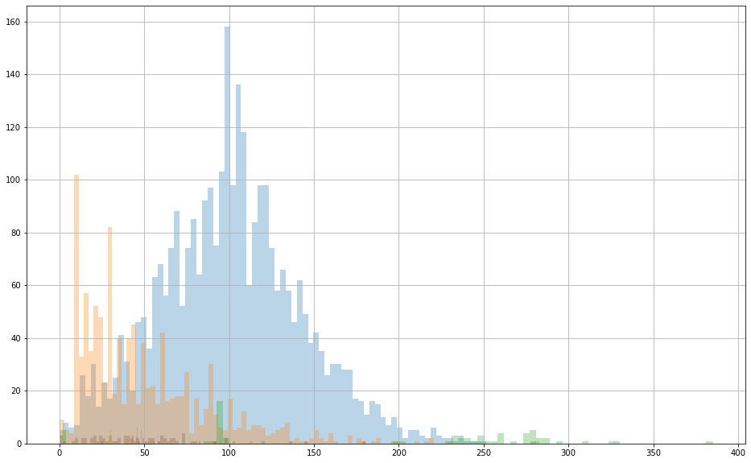

```python
for column in data_wire.columns:
    if column[0] == 'W':
        data_wire[column].hist(bins=100, figsize=(16,10), alpha=0.3)
```

#### Wire materials data (time):

```python
data_wire_time = pd.read_csv(r'C:\Users\MaYu7006\Documents\info_math\yandex ds\final\data_wire_time.csv')
data_wire_time.head(10)
```

|  | key | Wire 1 | Wire 2 | Wire 3 | Wire 4 | Wire 5 | Wire 6 | Wire 7 | Wire 8 | Wire 9 |
| --- | --- | --- | --- | --- | --- | --- | --- | --- | --- | --- |
| 0 | 1 | 2019-05-03 11:11:41 | NaN | NaN | NaN | NaN | NaN | NaN | NaN | NaN |
| 1 | 2 | 2019-05-03 11:46:10 | NaN | NaN | NaN | NaN | NaN | NaN | NaN | NaN |
| 2 | 3 | 2019-05-03 12:13:47 | NaN | NaN | NaN | NaN | NaN | NaN | NaN | NaN |
| 3 | 4 | 2019-05-03 12:48:05 | NaN | NaN | NaN | NaN | NaN | NaN | NaN | NaN |
| 4 | 5 | 2019-05-03 13:18:15 | 2019-05-03 13:32:06 | NaN | NaN | NaN | NaN | NaN | NaN | NaN |
| 5 | 6 | 2019-05-03 13:59:02 | 2019-05-03 13:59:54 | NaN | NaN | NaN | NaN | NaN | NaN | NaN |
| 6 | 7 | 2019-05-03 14:28:46 | NaN | NaN | NaN | NaN | NaN | NaN | NaN | NaN |
| 7 | 8 | 2019-05-03 15:03:42 | NaN | NaN | NaN | NaN | NaN | NaN | NaN | NaN |
| 8 | 9 | 2019-05-03 15:42:43 | 2019-05-03 15:58:12 | NaN | NaN | NaN | NaN | NaN | NaN | NaN |
| 9 | 10 | 2019-05-03 16:20:25 | 2019-05-03 16:21:02 | NaN | NaN | NaN | NaN | NaN | NaN | NaN |

```python
data_wire_time.info()
```

```
<class 'pandas.core.frame.DataFrame'>
RangeIndex: 3081 entries, 0 to 3080
Data columns (total 10 columns):
 #   Column  Non-Null Count  Dtype
---  ------  --------------  -----
 0   key     3081 non-null   int64
 1   Wire 1  3055 non-null   object
 2   Wire 2  1079 non-null   object
 3   Wire 3  63 non-null     object
 4   Wire 4  14 non-null     object
 5   Wire 5  1 non-null      object
 6   Wire 6  73 non-null     object
 7   Wire 7  11 non-null     object
 8   Wire 8  19 non-null     object
 9   Wire 9  29 non-null     object
dtypes: int64(1), object(9)
memory usage: 240.8+ KB
```

```python
data_wire_time['key'].unique()
```

```
array([   1,    2,    3, ..., 3239, 3240, 3241], dtype=int64)
```

```python
for column in data_wire_time.columns:
    print(column)
    display(data_wire_time[column].describe())
```

```
key
```

```
count    3081.000000
mean     1623.426485
std       932.996726
min         1.000000
25%       823.000000
50%      1619.000000
75%      2434.000000
max      3241.000000
Name: key, dtype: float64
```

```
Wire 1
```

```
count                    3055
unique                   3055
top       2019-07-18 06:55:47
freq                        1
Name: Wire 1, dtype: object
```

```
Wire 2
```

```
count                    1079
unique                   1079
top       2019-06-15 06:31:16
freq                        1
Name: Wire 2, dtype: object
```

```
Wire 3
```

```
count                      63
unique                     63
top       2019-05-07 17:43:23
freq                        1
Name: Wire 3, dtype: object
```

```
Wire 4
```

```
count                      14
unique                     14
top       2019-07-23 14:40:29
freq                        1
Name: Wire 4, dtype: object
```

```
Wire 5
```

```
count                       1
unique                      1
top       2019-08-08 16:01:07
freq                        1
Name: Wire 5, dtype: object
```

```
Wire 6
```

```
count                      73
unique                     73
top       2019-07-23 11:53:52
freq                        1
Name: Wire 6, dtype: object
```

```
Wire 7
```

```
count                      11
unique                     11
top       2019-08-08 16:45:44
freq                        1
Name: Wire 7, dtype: object
```

```
Wire 8
```

```
count                      19
unique                     19
top       2019-07-18 17:36:23
freq                        1
Name: Wire 8, dtype: object
```

```
Wire 9
```

```
count                      29
unique                     29
top       2019-06-07 21:42:24
freq                        1
Name: Wire 9, dtype: object
```

### Conclusion:

We imported data, plotted for each table to see the distribution of data, looked at general information. There are missing values in the data that will later need to be replaced or removed. Many columns are of float data type even though they store integers, so the data type will need to be changed. For convenience, we will rename the columns so that they are in English, without gaps and without capital letters. We have columns with time and they need to be converted to datetime format. In the data_arc table, the 'Reactive power' column had one anomalous value, so we immediately deleted it. We need to prepare the data and further group it by 'key'.

## Preparing signs.

To make it more convenient to work in the future, we will convert the data_arc table. Let's find the sum of each energy for each key:

```python
data_arc.columns = ['key', 'start_time','end_time', 'active_power', 'reactive_power']
data_arc_all = pd.pivot_table(data_arc,
                             values=['active_power','reactive_power'],
                             index='key',
                             aggfunc={'active_power': np.sum,
                                      'reactive_power': np.sum})
data_arc_all.columns = ['sum_active_power','sum_reactive_power']
data_arc_all.head()
```

| key | sum_active_power | sum_reactive_power |
| --- | --- | --- |
| 1 | 4.878147 | 3.183241 |
| 2 | 3.052598 | 1.998112 |
| 3 | 2.525882 | 1.599076 |
| 4 | 3.209250 | 2.060298 |
| 5 | 3.347173 | 2.252643 |

We need to delete from the table the keys that do not have a final measurement or have only one temperature measurement, since this data can spoil the statistics. To do this, we turn to the data_temp table. Let's make a separate list with all keys that are not suitable for us, so that later we can delete them in all tables.

```python
bad = []
for key in list(data_temp['key'].unique()):
    try:
        if ((data_temp[data_temp['key'] == key]['Время замера'].max() <
            data_arc[data_arc['key'] == key]['end_time'].max()) or
           (data_temp[data_temp['key'] == key]['Время замера'].max() ==
            data_temp[data_temp['key'] == key]['Время замера'].min())):
            bad.append(key)
    except:
        bad.append(key)
```

In the data_bulk table, we have a different amount of data for each column. Let's first make the 'key' column an index and change all the columns for convenience. We also have only one value in the 'Bulk 8' column, so it's best to delete it right away.

```python
data_bulk = data_bulk.set_index('key')
```

```python
data_bulk.columns = ['bulk_1', 'bulk_2', 'bulk_3', 'bulk_4', 'bulk_5', 'bulk_6', 'bulk_7', 'bulk_8', 'bulk_9', 'bulk_10', 'bulk_11', 'bulk_12', 'bulk_13', 'bulk_14', 'bulk_15']
```

```python
data_bulk = data_bulk.drop(columns= 'bulk_8')
```

In the data_gas table, let's make the 'key' column indox and, for convenience, name the second column differently.

```python
data_gas = data_gas.set_index('key')
data_gas.columns = ['gas']
```

In the data_wire table, let's make the 'key' column indox, rename the columns, and delete 'Wire 5' because it has too little data.

```python
data_wire = data_wire.set_index('key')
data_wire.columns = ['wire_1', 'wire_2', 'wire_3', 'wire_4', 'wire_5', 'wire_6', 'wire_7', 'wire_8', 'wire_9']
data_wire = data_wire.drop(columns= 'wire_5')
```

In the data_temp table, we need to delete all rows that do not suit us (their 'key' values are in list 'bad'). And we also need to remove the missing values.

```python
data_temp = data_temp.dropna()
data_temp.info()
```

```
<class 'pandas.core.frame.DataFrame'>
Int64Index: 13006 entries, 0 to 15902
Data columns (total 3 columns):
 #   Column        Non-Null Count  Dtype
---  ------        --------------  -----
 0   key           13006 non-null  int64
 1   Время замера  13006 non-null  object
 2   Температура   13006 non-null  float64
dtypes: float64(1), int64(1), object(1)
memory usage: 406.4+ KB
```

```python
data_temp = data_temp.query('key not in @bad')
data_temp.info()
```

```
<class 'pandas.core.frame.DataFrame'>
Int64Index: 12381 entries, 0 to 15902
Data columns (total 3 columns):
 #   Column        Non-Null Count  Dtype
---  ------        --------------  -----
 0   key           12381 non-null  int64
 1   Время замера  12381 non-null  object
 2   Температура   12381 non-null  float64
dtypes: float64(1), int64(1), object(1)
memory usage: 386.9+ KB
```

```python
count = (data_temp['key'].value_counts() < 2).sum()
count
```

```
701
```

```python
bad_key = list(data_temp['key'].value_counts().index[:count])
bad_key
```

[output not shown]

[output cut: 646 more lines]

```
 2056,
 1306,
 2000,
 1530,
 145,
 1094,
 778,
 903,
 1330,
 1928,
 1175,
 17,
 1054,
 727,
 1482]
```

```python
data_temp = data_temp.query('key not in @bad_key')
```

We need to find the start and end time of the measurement, for this we turn to data_temp and make a new table with the value of the initial and final measurement for each key:

```python
data_temp.head()
```

|  | key | Время замера | Температура |
| --- | --- | --- | --- |
| 0 | 1 | 2019-05-03 11:16:18 | 1571.0 |
| 1 | 1 | 2019-05-03 11:25:53 | 1604.0 |
| 2 | 1 | 2019-05-03 11:29:11 | 1618.0 |
| 3 | 1 | 2019-05-03 11:30:01 | 1601.0 |
| 4 | 1 | 2019-05-03 11:30:39 | 1613.0 |

```python
data_temp_time = pd.pivot_table(data_temp,
                                values='Время замера',
                                index='key',
                                aggfunc={'Время замера': [np.min, np.max]})
data_temp_time
```

| key | amax | amin |
| --- | --- | --- |
| 1 | 2019-05-03 11:30:39 | 2019-05-03 11:16:18 |
| 3 | 2019-05-03 12:34:57 | 2019-05-03 12:13:17 |
| 4 | 2019-05-03 12:59:25 | 2019-05-03 12:52:57 |
| 5 | 2019-05-03 13:36:01 | 2019-05-03 13:23:19 |
| 6 | 2019-05-03 14:12:29 | 2019-05-03 13:49:24 |
| ... | ... | ... |
| 3237 | 2019-08-31 22:44:04 | 2019-08-31 22:44:04 |
| 3238 | 2019-08-31 23:30:31 | 2019-08-31 23:30:31 |
| 3239 | 2019-09-01 01:31:47 | 2019-09-01 01:31:47 |
| 3240 | 2019-09-01 02:39:01 | 2019-09-01 02:39:01 |
| 3241 | 2019-09-01 04:03:30 | 2019-09-01 04:03:30 |

2344 rows × 2 columns

```python
data_temp.columns = ['key', 'time','temp']
```

We will build a table in which we will display the temperature at the beginning and at the end of the measurement. To do this, we use the tables 'data_temp' and 'data_temp_time'.

```python
end= list(data_temp_time['amax'])
start = list(data_temp_time['amin'])
temp_end = data_temp.query('time in @end')
temp_end = temp_end.set_index('key')
temp_start= data_temp.query('time in @start')
temp_start = temp_start.set_index('key')
data_temp_all = temp_start.copy()
data_temp_all.columns = ['time','start_t']
data_temp_all['end_t'] = temp_end['temp']
data_temp_all = data_temp_all.drop('time', axis=1)
data_temp_all.head()
```

| key | start_t | end_t |
| --- | --- | --- |
| 1 | 1571.0 | 1613.0 |
| 3 | 1596.0 | 1599.0 |
| 4 | 1601.0 | 1625.0 |
| 5 | 1576.0 | 1602.0 |
| 6 | 1543.0 | 1596.0 |

Ultimately, we need to build a model that predicts the temperature of the steel. That is, we will need to predict the value of end_temp, which depends on variables in other tables. To do this, we will combine all the data in one table:

```python
data_final = pd.concat([data_arc_all, data_temp_all, data_bulk, data_gas, data_wire], axis=1, sort=False)
# data_final = data_steel.dropna(subset=['end_temp'])
data_final.head()
```

| key | sum_active_power | sum_reactive_power | start_t | end_t | bulk_1 | bulk_2 | bulk_3 | bulk_4 | bulk_5 | bulk_6 | ... | bulk_15 | gas | wire_1 | wire_2 | wire_3 | wire_4 | wire_6 | wire_7 | wire_8 | wire_9 |
| --- | --- | --- | --- | --- | --- | --- | --- | --- | --- | --- | --- | --- | --- | --- | --- | --- | --- | --- | --- | --- | --- |
| 1 | 4.878147 | 3.183241 | 1571.0 | 1613.0 | NaN | NaN | NaN | 43.0 | NaN | NaN | ... | 154.0 | 29.749986 | 60.059998 | NaN | NaN | NaN | NaN | NaN | NaN | NaN |
| 2 | 3.052598 | 1.998112 | NaN | NaN | NaN | NaN | NaN | 73.0 | NaN | NaN | ... | 154.0 | 12.555561 | 96.052315 | NaN | NaN | NaN | NaN | NaN | NaN | NaN |
| 3 | 2.525882 | 1.599076 | 1596.0 | 1599.0 | NaN | NaN | NaN | 34.0 | NaN | NaN | ... | 153.0 | 28.554793 | 91.160157 | NaN | NaN | NaN | NaN | NaN | NaN | NaN |
| 4 | 3.209250 | 2.060298 | 1601.0 | 1625.0 | NaN | NaN | NaN | 81.0 | NaN | NaN | ... | 154.0 | 18.841219 | 89.063515 | NaN | NaN | NaN | NaN | NaN | NaN | NaN |
| 5 | 3.347173 | 2.252643 | 1576.0 | 1602.0 | NaN | NaN | NaN | 78.0 | NaN | NaN | ... | 152.0 | 5.413692 | 89.238236 | 9.11456 | NaN | NaN | NaN | NaN | NaN | NaN |

5 rows × 27 columns

```python
data_final.info()
```

```
<class 'pandas.core.frame.DataFrame'>
Int64Index: 3241 entries, 1 to 3241
Data columns (total 27 columns):
 #   Column              Non-Null Count  Dtype
---  ------              --------------  -----
 0   sum_active_power    3214 non-null   float64
 1   sum_reactive_power  3214 non-null   float64
 2   start_t             2344 non-null   float64
 3   end_t               2344 non-null   float64
 4   bulk_1              252 non-null    float64
 5   bulk_2              22 non-null     float64
 6   bulk_3              1298 non-null   float64
 7   bulk_4              1014 non-null   float64
 8   bulk_5              77 non-null     float64
 9   bulk_6              576 non-null    float64
```

[output cut: 19 more lines]

We have a lot of missing values and for convenience we will replace them with 0.

```python
data_final = data_final.fillna(0)
```

After replacing NaN with 0, start_t and end_t may appear in the table at the same time equal to 0 and it is better to get rid of them:

```python
datas = data_final.query('start_t == 0 and start_t == 0')
datas
```

|  | sum_active_power | sum_reactive_power | start_t | end_t | bulk_1 | bulk_2 | bulk_3 | bulk_4 | bulk_5 | bulk_6 | ... | bulk_15 | gas | wire_1 | wire_2 | wire_3 | wire_4 | wire_6 | wire_7 | wire_8 | wire_9 |
| --- | --- | --- | --- | --- | --- | --- | --- | --- | --- | --- | --- | --- | --- | --- | --- | --- | --- | --- | --- | --- | --- |
| key |  |  |  |  |  |  |  |  |  |  |  |  |  |  |  |  |  |  |  |  |  |

0 rows × 27 columns

```python
data_final = data_final.query('start_t != 0 and start_t != 0')
data_final
```

| key | sum_active_power | sum_reactive_power | start_t | end_t | bulk_1 | bulk_2 | bulk_3 | bulk_4 | bulk_5 | bulk_6 | ... | bulk_15 | gas | wire_1 | wire_2 | wire_3 | wire_4 | wire_6 | wire_7 | wire_8 | wire_9 |
| --- | --- | --- | --- | --- | --- | --- | --- | --- | --- | --- | --- | --- | --- | --- | --- | --- | --- | --- | --- | --- | --- |
| 1 | 4.878147 | 3.183241 | 1571.0 | 1613.0 | 0.0 | 0.0 | 0.0 | 43.0 | 0.0 | 0.0 | ... | 154.0 | 29.749986 | 60.059998 | 0.00000 | 0.0 | 0.0 | 0.0 | 0.0 | 0.0 | 0.0 |
| 3 | 2.525882 | 1.599076 | 1596.0 | 1599.0 | 0.0 | 0.0 | 0.0 | 34.0 | 0.0 | 0.0 | ... | 153.0 | 28.554793 | 91.160157 | 0.00000 | 0.0 | 0.0 | 0.0 | 0.0 | 0.0 | 0.0 |
| 4 | 3.209250 | 2.060298 | 1601.0 | 1625.0 | 0.0 | 0.0 | 0.0 | 81.0 | 0.0 | 0.0 | ... | 154.0 | 18.841219 | 89.063515 | 0.00000 | 0.0 | 0.0 | 0.0 | 0.0 | 0.0 | 0.0 |
| 5 | 3.347173 | 2.252643 | 1576.0 | 1602.0 | 0.0 | 0.0 | 0.0 | 78.0 | 0.0 | 0.0 | ... | 152.0 | 5.413692 | 89.238236 | 9.11456 | 0.0 | 0.0 | 0.0 | 0.0 | 0.0 | 0.0 |
| 6 | 3.955108 | 2.689175 | 1543.0 | 1596.0 | 0.0 | 0.0 | 0.0 | 117.0 | 0.0 | 0.0 | ... | 154.0 | 11.273392 | 99.109917 | 9.11456 | 0.0 | 0.0 | 0.0 | 0.0 | 0.0 | 0.0 |
| ... | ... | ... | ... | ... | ... | ... | ... | ... | ... | ... | ... | ... | ... | ... | ... | ... | ... | ... | ... | ... | ... |
| 3237 | 3.932467 | 2.828459 | 1569.0 | 1569.0 | 0.0 | 0.0 | 170.0 | 0.0 | 0.0 | 0.0 | ... | 206.0 | 5.543905 | 38.088959 | 0.00000 | 0.0 | 0.0 | 0.0 | 0.0 | 0.0 | 0.0 |
| 3238 | 2.106529 | 1.681182 | 1584.0 | 1584.0 | 0.0 | 0.0 | 126.0 | 0.0 | 0.0 | 0.0 | ... | 106.0 | 6.745669 | 56.128799 | 0.00000 | 0.0 | 0.0 | 0.0 | 0.0 | 0.0 | 0.0 |
| 3239 | 4.666754 | 3.111617 | 1598.0 | 1598.0 | 0.0 | 0.0 | 0.0 | 0.0 | 0.0 | 114.0 | ... | 88.0 | 16.023518 | 143.357761 | 0.00000 | 0.0 | 0.0 | 0.0 | 0.0 | 0.0 | 0.0 |
| 3240 | 2.984083 | 2.483267 | 1617.0 | 1617.0 | 0.0 | 0.0 | 0.0 | 0.0 | 0.0 | 26.0 | ... | 54.0 | 11.863103 | 34.070400 | 0.00000 | 0.0 | 0.0 | 0.0 | 0.0 | 0.0 | 0.0 |
| 3241 | 2.471447 | 1.696199 | 1586.0 | 1586.0 | 0.0 | 0.0 | 0.0 | 0.0 | 0.0 | 0.0 | ... | 52.0 | 12.680959 | 63.117595 | 0.00000 | 0.0 | 0.0 | 0.0 | 0.0 | 0.0 | 0.0 |

2344 rows × 27 columns

```python
data_final = data_final.astype(
    {"start_t":'int16',
     "end_t":'int16',
     "bulk_1":'int16',
     "bulk_2":'int16',
     "bulk_3":'int16',
     "bulk_4":'int16',
     "bulk_5":'int16',
     "bulk_6":'int16',
     "bulk_7":'int16',
     "bulk_9":'int16',
     "bulk_10":'int16',
     "bulk_11":'int16',
     "bulk_12":'int16',
     "bulk_13":'int16',
     "bulk_14":'int16',
     "bulk_15":'int16'})
```

```python
data_final.info()
```

```
<class 'pandas.core.frame.DataFrame'>
Int64Index: 2344 entries, 1 to 3241
Data columns (total 27 columns):
 #   Column              Non-Null Count  Dtype
---  ------              --------------  -----
 0   sum_active_power    2344 non-null   float64
 1   sum_reactive_power  2344 non-null   float64
 2   start_t             2344 non-null   int16
 3   end_t               2344 non-null   int16
 4   bulk_1              2344 non-null   int16
 5   bulk_2              2344 non-null   int16
 6   bulk_3              2344 non-null   int16
 7   bulk_4              2344 non-null   int16
 8   bulk_5              2344 non-null   int16
 9   bulk_6              2344 non-null   int16
```

[output cut: 19 more lines]

Let's look at the table to see the dependence.

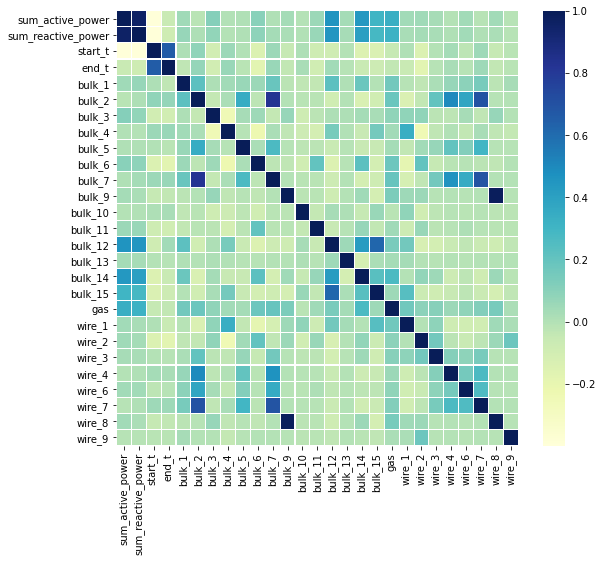

```python
corrmat = data_final.corr()



f, ax = plt.subplots(figsize =(9, 8))

sns.heatmap(corrmat, ax = ax, cmap ="YlGnBu", linewidths = 0.1)
```

Find the correlation coefficient for end_t with all other columns:

```python
data_final.corr()['end_t']
```

```
sum_active_power     -0.059216
sum_reactive_power   -0.077656
start_t               0.661016
end_t                 1.000000
bulk_1               -0.027918
bulk_2                0.074529
bulk_3               -0.094788
bulk_4                0.061639
bulk_5               -0.015463
bulk_6               -0.169559
bulk_7                0.063812
bulk_9               -0.036205
bulk_10               0.024938
bulk_11              -0.087560
bulk_12               0.042592
bulk_13              -0.010229
bulk_14              -0.057375
bulk_15              -0.071405
gas                  -0.033888
wire_1               -0.056109
wire_2               -0.169870
wire_3               -0.006122
wire_4                0.022223
wire_6               -0.008807
wire_7                0.054395
wire_8               -0.037083
wire_9               -0.016177
Name: end_t, dtype: float64
```

```python
data_model = data_final.copy()
data_model
```

| key | sum_active_power | sum_reactive_power | start_t | end_t | bulk_1 | bulk_2 | bulk_3 | bulk_4 | bulk_5 | bulk_6 | ... | bulk_15 | gas | wire_1 | wire_2 | wire_3 | wire_4 | wire_6 | wire_7 | wire_8 | wire_9 |
| --- | --- | --- | --- | --- | --- | --- | --- | --- | --- | --- | --- | --- | --- | --- | --- | --- | --- | --- | --- | --- | --- |
| 1 | 4.878147 | 3.183241 | 1571 | 1613 | 0 | 0 | 0 | 43 | 0 | 0 | ... | 154 | 29.749986 | 60.059998 | 0.00000 | 0.0 | 0.0 | 0.0 | 0.0 | 0.0 | 0.0 |
| 3 | 2.525882 | 1.599076 | 1596 | 1599 | 0 | 0 | 0 | 34 | 0 | 0 | ... | 153 | 28.554793 | 91.160157 | 0.00000 | 0.0 | 0.0 | 0.0 | 0.0 | 0.0 | 0.0 |
| 4 | 3.209250 | 2.060298 | 1601 | 1625 | 0 | 0 | 0 | 81 | 0 | 0 | ... | 154 | 18.841219 | 89.063515 | 0.00000 | 0.0 | 0.0 | 0.0 | 0.0 | 0.0 | 0.0 |
| 5 | 3.347173 | 2.252643 | 1576 | 1602 | 0 | 0 | 0 | 78 | 0 | 0 | ... | 152 | 5.413692 | 89.238236 | 9.11456 | 0.0 | 0.0 | 0.0 | 0.0 | 0.0 | 0.0 |
| 6 | 3.955108 | 2.689175 | 1543 | 1596 | 0 | 0 | 0 | 117 | 0 | 0 | ... | 154 | 11.273392 | 99.109917 | 9.11456 | 0.0 | 0.0 | 0.0 | 0.0 | 0.0 | 0.0 |
| ... | ... | ... | ... | ... | ... | ... | ... | ... | ... | ... | ... | ... | ... | ... | ... | ... | ... | ... | ... | ... | ... |
| 3237 | 3.932467 | 2.828459 | 1569 | 1569 | 0 | 0 | 170 | 0 | 0 | 0 | ... | 206 | 5.543905 | 38.088959 | 0.00000 | 0.0 | 0.0 | 0.0 | 0.0 | 0.0 | 0.0 |
| 3238 | 2.106529 | 1.681182 | 1584 | 1584 | 0 | 0 | 126 | 0 | 0 | 0 | ... | 106 | 6.745669 | 56.128799 | 0.00000 | 0.0 | 0.0 | 0.0 | 0.0 | 0.0 | 0.0 |
| 3239 | 4.666754 | 3.111617 | 1598 | 1598 | 0 | 0 | 0 | 0 | 0 | 114 | ... | 88 | 16.023518 | 143.357761 | 0.00000 | 0.0 | 0.0 | 0.0 | 0.0 | 0.0 | 0.0 |
| 3240 | 2.984083 | 2.483267 | 1617 | 1617 | 0 | 0 | 0 | 0 | 0 | 26 | ... | 54 | 11.863103 | 34.070400 | 0.00000 | 0.0 | 0.0 | 0.0 | 0.0 | 0.0 | 0.0 |
| 3241 | 2.471447 | 1.696199 | 1586 | 1586 | 0 | 0 | 0 | 0 | 0 | 0 | ... | 52 | 12.680959 | 63.117595 | 0.00000 | 0.0 | 0.0 | 0.0 | 0.0 | 0.0 | 0.0 |

2344 rows × 27 columns

```python
data_final
```

| key | sum_active_power | sum_reactive_power | start_t | end_t | bulk_1 | bulk_2 | bulk_3 | bulk_4 | bulk_5 | bulk_6 | ... | bulk_15 | gas | wire_1 | wire_2 | wire_3 | wire_4 | wire_6 | wire_7 | wire_8 | wire_9 |
| --- | --- | --- | --- | --- | --- | --- | --- | --- | --- | --- | --- | --- | --- | --- | --- | --- | --- | --- | --- | --- | --- |
| 1 | 4.878147 | 3.183241 | 1571 | 1613 | 0 | 0 | 0 | 43 | 0 | 0 | ... | 154 | 29.749986 | 60.059998 | 0.00000 | 0.0 | 0.0 | 0.0 | 0.0 | 0.0 | 0.0 |
| 3 | 2.525882 | 1.599076 | 1596 | 1599 | 0 | 0 | 0 | 34 | 0 | 0 | ... | 153 | 28.554793 | 91.160157 | 0.00000 | 0.0 | 0.0 | 0.0 | 0.0 | 0.0 | 0.0 |
| 4 | 3.209250 | 2.060298 | 1601 | 1625 | 0 | 0 | 0 | 81 | 0 | 0 | ... | 154 | 18.841219 | 89.063515 | 0.00000 | 0.0 | 0.0 | 0.0 | 0.0 | 0.0 | 0.0 |
| 5 | 3.347173 | 2.252643 | 1576 | 1602 | 0 | 0 | 0 | 78 | 0 | 0 | ... | 152 | 5.413692 | 89.238236 | 9.11456 | 0.0 | 0.0 | 0.0 | 0.0 | 0.0 | 0.0 |
| 6 | 3.955108 | 2.689175 | 1543 | 1596 | 0 | 0 | 0 | 117 | 0 | 0 | ... | 154 | 11.273392 | 99.109917 | 9.11456 | 0.0 | 0.0 | 0.0 | 0.0 | 0.0 | 0.0 |
| ... | ... | ... | ... | ... | ... | ... | ... | ... | ... | ... | ... | ... | ... | ... | ... | ... | ... | ... | ... | ... | ... |
| 3237 | 3.932467 | 2.828459 | 1569 | 1569 | 0 | 0 | 170 | 0 | 0 | 0 | ... | 206 | 5.543905 | 38.088959 | 0.00000 | 0.0 | 0.0 | 0.0 | 0.0 | 0.0 | 0.0 |
| 3238 | 2.106529 | 1.681182 | 1584 | 1584 | 0 | 0 | 126 | 0 | 0 | 0 | ... | 106 | 6.745669 | 56.128799 | 0.00000 | 0.0 | 0.0 | 0.0 | 0.0 | 0.0 | 0.0 |
| 3239 | 4.666754 | 3.111617 | 1598 | 1598 | 0 | 0 | 0 | 0 | 0 | 114 | ... | 88 | 16.023518 | 143.357761 | 0.00000 | 0.0 | 0.0 | 0.0 | 0.0 | 0.0 | 0.0 |
| 3240 | 2.984083 | 2.483267 | 1617 | 1617 | 0 | 0 | 0 | 0 | 0 | 26 | ... | 54 | 11.863103 | 34.070400 | 0.00000 | 0.0 | 0.0 | 0.0 | 0.0 | 0.0 | 0.0 |
| 3241 | 2.471447 | 1.696199 | 1586 | 1586 | 0 | 0 | 0 | 0 | 0 | 0 | ... | 52 | 12.680959 | 63.117595 | 0.00000 | 0.0 | 0.0 | 0.0 | 0.0 | 0.0 | 0.0 |

2344 rows × 27 columns

```python
data_model = data_model.drop('sum_reactive_power', axis=1)
data_model = data_model.drop('bulk_1', axis=1)
data_model = data_model.drop('bulk_4', axis=1)
data_model = data_model.drop('bulk_5', axis=1)
data_model = data_model.drop('bulk_7', axis=1)
data_model = data_model.drop('bulk_9', axis=1)
data_model = data_model.drop('bulk_10', axis=1)
data_model = data_model.drop('bulk_13', axis=1)
data_model = data_model.drop('bulk_14', axis=1)
data_model = data_model.drop('bulk_15', axis=1)
data_model = data_model.drop('gas', axis=1)
data_model = data_model.drop('wire_1', axis=1)
data_model = data_model.drop('wire_3', axis=1)
data_model = data_model.drop('wire_4', axis=1)
data_model = data_model.drop('wire_6', axis=1)
data_model = data_model.drop('wire_8', axis=1)
data_model = data_model.drop('wire_9', axis=1)
data_model.head()
```

| key | sum_active_power | start_t | end_t | bulk_2 | bulk_3 | bulk_6 | bulk_11 | bulk_12 | wire_2 | wire_7 |
| --- | --- | --- | --- | --- | --- | --- | --- | --- | --- | --- |
| 1 | 4.878147 | 1571 | 1613 | 0 | 0 | 0 | 0 | 206 | 0.00000 | 0.0 |
| 3 | 2.525882 | 1596 | 1599 | 0 | 0 | 0 | 0 | 205 | 0.00000 | 0.0 |
| 4 | 3.209250 | 1601 | 1625 | 0 | 0 | 0 | 0 | 207 | 0.00000 | 0.0 |
| 5 | 3.347173 | 1576 | 1602 | 0 | 0 | 0 | 0 | 203 | 9.11456 | 0.0 |
| 6 | 3.955108 | 1543 | 1596 | 0 | 0 | 0 | 0 | 204 | 9.11456 | 0.0 |

```python
data_model
```

| key | sum_active_power | start_t | end_t | bulk_2 | bulk_3 | bulk_6 | bulk_11 | bulk_12 | wire_2 | wire_7 |
| --- | --- | --- | --- | --- | --- | --- | --- | --- | --- | --- |
| 1 | 4.878147 | 1571 | 1613 | 0 | 0 | 0 | 0 | 206 | 0.00000 | 0.0 |
| 3 | 2.525882 | 1596 | 1599 | 0 | 0 | 0 | 0 | 205 | 0.00000 | 0.0 |
| 4 | 3.209250 | 1601 | 1625 | 0 | 0 | 0 | 0 | 207 | 0.00000 | 0.0 |
| 5 | 3.347173 | 1576 | 1602 | 0 | 0 | 0 | 0 | 203 | 9.11456 | 0.0 |
| 6 | 3.955108 | 1543 | 1596 | 0 | 0 | 0 | 0 | 204 | 9.11456 | 0.0 |
| ... | ... | ... | ... | ... | ... | ... | ... | ... | ... | ... |
| 3237 | 3.932467 | 1569 | 1569 | 0 | 170 | 0 | 0 | 252 | 0.00000 | 0.0 |
| 3238 | 2.106529 | 1584 | 1584 | 0 | 126 | 0 | 0 | 254 | 0.00000 | 0.0 |
| 3239 | 4.666754 | 1598 | 1598 | 0 | 0 | 114 | 0 | 158 | 0.00000 | 0.0 |
| 3240 | 2.984083 | 1617 | 1617 | 0 | 0 | 26 | 0 | 0 | 0.00000 | 0.0 |
| 3241 | 2.471447 | 1586 | 1586 | 0 | 0 | 0 | 0 | 0 | 0.00000 | 0.0 |

2344 rows × 10 columns

## Learning and testing models.

```python
from sklearn import tree
import seaborn as sns
%matplotlib inline
```

```python
max_depth_values=range(1,100)
scores_data = pd.DataFrame()
clf = tree.DecisionTreeClassifier(criterion = 'entropy', max_depth=3)
```

```python
model
```

[output not shown]

```python
data_model.info()
```

```
<class 'pandas.core.frame.DataFrame'>
Int64Index: 2344 entries, 1 to 3241
Data columns (total 10 columns):
 #   Column            Non-Null Count  Dtype
---  ------            --------------  -----
 0   sum_active_power  2344 non-null   float64
 1   start_t           2344 non-null   int16
 2   end_t             2344 non-null   int16
 3   bulk_2            2344 non-null   int16
 4   bulk_3            2344 non-null   int16
 5   bulk_6            2344 non-null   int16
 6   bulk_11           2344 non-null   int16
 7   bulk_12           2344 non-null   int16
 8   wire_2            2344 non-null   float64
 9   wire_7            2344 non-null   float64
dtypes: float64(3), int16(7)
memory usage: 105.3 KB
```

We divide the data into features and target, and then we divide it into training and test samples in a ratio of 75:25.

```python
random_state = 4102020
# features = data_steel.drop('end_temp', axis=1)
# target = data_steel['end_temp']

features = data_model.drop('end_t', axis=1)
target = data_model['end_t']

features_train, features_test, target_train, target_test = train_test_split(
                                                            features,
                                                            target,
                                                            test_size=0.25,
                                                            random_state=random_state)
cv_counts = 5
```

```python
joblib.dump(model, 'slope_from_sentiment_model.pkl')

mae = mean_absolute_error(target_test, model.predict(features_test))
mae
```

[output not shown]

```python
model = LogisticRegression()
model.fit(features_train, target_train)
# save the model to disk
filename = 'finalized_model.sav'
joblib.dump(model, filename)

# some time later...

# load the model from disk
loaded_model = joblib.load(filename)
result = loaded_model.score(X_test, Y_test)
print(result)
```

```python
import joblib
```

```python
from sklearn.metrics import mean_absolute_error
from sklearn.externals import joblib
```

[output not shown]

```python
model.fit(features_train, target_train)
```

```
<catboost.core.CatBoostRegressor at 0x240a1600910>
```

```python
joblib.dump(model, 'slope_from_sentiment_model.pkl')

mae = mean_absolute_error(target_train, model.predict(features_train))
mae
```

[output not shown]

```python
print(features_train.shape)
print(features_test.shape)
print(target_train.shape)
print(target_test.shape)
```

```
(1758, 9)
(586, 9)
(1758,)
(586,)
```

```python
features_train
```

| key | sum_active_power | start_t | bulk_2 | bulk_3 | bulk_6 | bulk_11 | bulk_12 | wire_2 | wire_7 |
| --- | --- | --- | --- | --- | --- | --- | --- | --- | --- |
| 1775 | 1.816811 | 1604 | 0 | 21 | 0 | 0 | 205 | 0.000000 | 0.0 |
| 677 | 3.756417 | 1601 | 0 | 93 | 0 | 0 | 331 | 0.000000 | 0.0 |
| 2681 | 2.362018 | 1579 | 0 | 208 | 0 | 0 | 276 | 35.106239 | 0.0 |
| 217 | 2.631394 | 1591 | 0 | 0 | 0 | 0 | 123 | 0.000000 | 0.0 |
| 967 | 3.305759 | 1568 | 0 | 0 | 0 | 0 | 204 | 115.331833 | 0.0 |
| ... | ... | ... | ... | ... | ... | ... | ... | ... | ... |
| 1410 | 4.945183 | 1604 | 0 | 0 | 150 | 0 | 281 | 150.407913 | 0.0 |
| 2811 | 2.052920 | 1593 | 0 | 0 | 0 | 0 | 206 | 0.000000 | 0.0 |
| 2350 | 2.757768 | 1570 | 0 | 0 | 0 | 0 | 256 | 0.000000 | 0.0 |
| 1053 | 3.311512 | 1568 | 0 | 0 | 0 | 0 | 207 | 0.000000 | 0.0 |
| 2682 | 3.485891 | 1574 | 0 | 152 | 0 | 0 | 244 | 21.323120 | 0.0 |

1758 rows × 9 columns

```python
features
```

| key | sum_active_power | start_t | bulk_2 | bulk_3 | bulk_6 | bulk_11 | bulk_12 | wire_2 | wire_7 |
| --- | --- | --- | --- | --- | --- | --- | --- | --- | --- |
| 1 | 4.878147 | 1571 | 0 | 0 | 0 | 0 | 206 | 0.00000 | 0.0 |
| 3 | 2.525882 | 1596 | 0 | 0 | 0 | 0 | 205 | 0.00000 | 0.0 |
| 4 | 3.209250 | 1601 | 0 | 0 | 0 | 0 | 207 | 0.00000 | 0.0 |
| 5 | 3.347173 | 1576 | 0 | 0 | 0 | 0 | 203 | 9.11456 | 0.0 |
| 6 | 3.955108 | 1543 | 0 | 0 | 0 | 0 | 204 | 9.11456 | 0.0 |
| ... | ... | ... | ... | ... | ... | ... | ... | ... | ... |
| 3237 | 3.932467 | 1569 | 0 | 170 | 0 | 0 | 252 | 0.00000 | 0.0 |
| 3238 | 2.106529 | 1584 | 0 | 126 | 0 | 0 | 254 | 0.00000 | 0.0 |
| 3239 | 4.666754 | 1598 | 0 | 0 | 114 | 0 | 158 | 0.00000 | 0.0 |
| 3240 | 2.984083 | 1617 | 0 | 0 | 26 | 0 | 0 | 0.00000 | 0.0 |
| 3241 | 2.471447 | 1586 | 0 | 0 | 0 | 0 | 0 | 0.00000 | 0.0 |

2344 rows × 9 columns

```python
model = LinearRegression()

MAE = (cross_val_score(model,
                             features_train,
                             target_train,
                             cv=cv_counts,
                             scoring='neg_mean_absolute_error').mean() * -1)
print('MAE model LinearRegression =', MAE)
```

```
MAE model LinearRegression = 9.878189224738673
```

```python
model.fit(features_train, target_train)
```

```
LinearRegression()
```

```python
joblib.dump(model, 'slope_from_sentiment_model.pkl')

mae = mean_absolute_error(target_train, model.predict(features_train))
mae
```

```
9.75632987468055
```

```python
best_model = None
best_result = 10000
best_est = 0
best_depth = 0
for est in range(1, 51, 10):
    for depth in range (1, 20):
        model = RandomForestRegressor(random_state=12345, n_estimators=est, max_depth=depth)
        model.fit(features_train, target_train)
        predictions_test= model.predict(features_test)
        result = mean_absolute_error(target_test, predictions_test)
        if result < best_result:
            best_model = model
            best_result = result
            best_est = est
            best_depth = depth

print("MAE наилучшей модели:", best_result, "Количество деревьев:", best_est, "Максимальная глубина:", depth)
```

```
MAE наилучшей модели: 9.606447934280713 Количество деревьев: 41 Максимальная глубина: 19
```

```python
model.fit(features_train, target_train)
```

```
RandomForestRegressor(max_depth=19, n_estimators=41, random_state=12345)
```

```python
joblib.dump(model, 'slope_from_sentiment_model.pkl')

mae = mean_absolute_error(target_train, model.predict(features_train))
mae
```

```
3.4661867352375846
```

```python
model.fit(features_test, target_test)
```

```
RandomForestRegressor(max_depth=19, n_estimators=41, random_state=12345)
```

```python
joblib.dump(model, 'slope_from_sentiment_model.pkl')

mae = mean_absolute_error(target_test, model.predict(features_test))
mae
```

```
4.054207477325898
```

```python
model = CatBoostRegressor(verbose=False, random_state=random_state)

MAE = (cross_val_score(model,
                             features_train,
                             target_train,
                             cv=cv_counts,
                             scoring='neg_mean_absolute_error').mean() * -1)
print('Mean MAE from CV of CatBoostRegressor =', MAE)
```

```
Mean MAE from CV of CatBoostRegressor = 9.235357914145904
```

```python
model.fit(features_train, target_train)
```

```
<catboost.core.CatBoostRegressor at 0x240a14bb790>
```

```python
joblib.dump(model, 'slope_from_sentiment_model.pkl')

mae = mean_absolute_error(target_train, model.predict(features_train))
mae
```

```
5.5372041601021404
```

```python
#pip install catboost
```

```python
from catboost import CatBoostRegressor
```

Let's train LinearRegression:

```python
model = LinearRegression()
model.fit(features_train, target_train)
target_predict = model.predict(features_test)
test_MAE_LR = mean_absolute_error(target_predict, target_test)
print('MAE on test for LinearRegression =', test_MAE_LR)
```

```
MAE on test for LinearRegression = 10.23356704661378
```

```python
model.fit(features_train, target_train)
```

```
LinearRegression()
```

```python
joblib.dump(model, 'slope_from_sentiment_model.pkl')

mae = mean_absolute_error(target_train, model.predict(features_train))
mae
```

```
9.75632987468055
```

Let's train CatBoostRegressor:

```python
model = CatBoostRegressor(verbose=False)
model.fit(features_train, target_train)
target_predict = model.predict(features_test)
test_MAE_CBR = mean_absolute_error(target_predict, target_test)
print('MAE on test of CatBoostRegressor =', test_MAE_CBR)
```

```
MAE on test of CatBoostRegressor = 9.650060413242798
```

```python
model.fit(features_train, target_train)
```

```
<catboost.core.CatBoostRegressor at 0x240a90e5d30>
```

```python
joblib.dump(model, 'slope_from_sentiment_model.pkl')

mae = mean_absolute_error(target_train, model.predict(features_train))
mae
```

```
5.462264501164419
```

# Final record.